# Finanzas Públicas

Cátedra Freille

Sebastián Freille

# Bibliografia

- Rosen, H. S. (2008). Hacienda Pública (7ma. edición). Madrid: McGraw-Hill/Interamericana. Capítulo 8, págs 55 a 65 y 165 a 190. Disponible:
- Garriga, M., & Rosales, W. (2013).Finanzas públicas en la práctica. Selección de casos y aplicaciones. Buenos Aires: Editorial Dunken. Capítulo 2, págs. 15 a 22. **Solicitar por: 336 G 53902.**
- Musgrave y Musgrave (1992). Hacienda Pública Teórica y Aplicada (5a. edición). Madrid: Mc. Graw Hill. Capítulo 8. **Solicitar por: T 336 M 38730**

# Incidencia impositiva

# Impuestos e incidencia

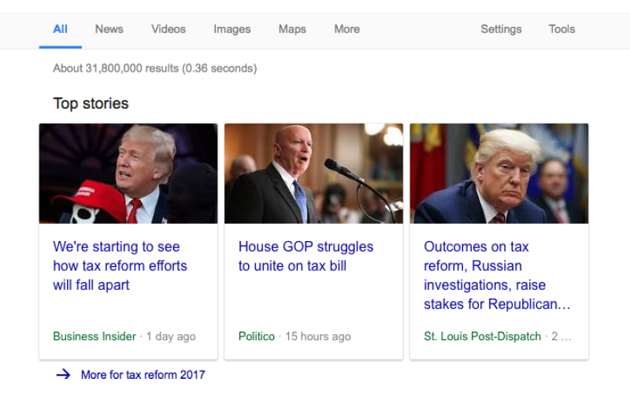

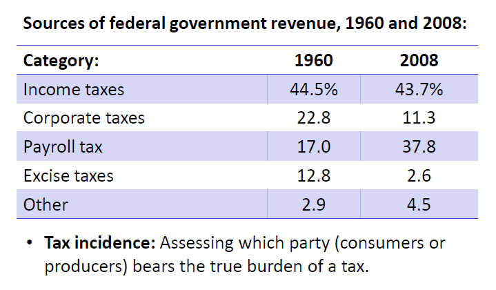

- El campo de la incidencia impositiva estudia los efectos de las políticas impositivas sobre los precios y el bienestar de los individuos
- ¿Qué pasa con el precio de mercado de un bien cuando se introduce un impuesto?
  - Ejemplo $\longrightarrow$ ¿qué pasa con el precio de cigarrillos cuando ponemos un impuesto de $1$ dolar por paquete?
- Efecto s/ precio $\longrightarrow$ efectos distributivos en consumidores (fumadores), productores, pero también accionistas, agricultores (tabaco)
- Involucra análisis positivo; normalmente, el primer paso para una evaluación de política para luego pensar políticas que maximicen el bienestar
- Implica una caracterización analítica de cambios en el equilibrio cuando se introducen impuestos
- Incidencia legal no tiene nada que ver con incidencia económica
- Punto central $\longrightarrow$ **impuestos pueden ser trasladados**; impuestos afectan $P$ en forma directa; y estos afectan $Q$ en forma indirecta (respuestas comportamentales); y estas afectan $P$ de otros bienes en forma indirecta
- Ejemplo $\longrightarrow$ liberales proponen gravar al $K$ (distribución altamente concentrada); esto implica gravar desproporcionalmente a los mas ricos
- Problema $\longrightarrow$ omite efectos de $P$ de equilibrio general –si los ricos ahorran menos, el stock de $K$ baja; puede bajar salario y afecta a trabajadores

# Incidencia: Equilibrio parcial

# Incidencia: Equilibrio parcial

- El gobierno pone un impuesto a las ventas (“excise tax”), $t$, sobre el bien $x$
- Se llama asi porque se impone sobre cantidades y es típicamente fijo en terminos nominales –1 dolar por cajita [diferente del “ad-valorem” que es un porcentaje sobre precio]
- Sea $p$ el precio antes de impuesto (ADI) del bien $x$ (precio del productor)
- Sea además $q=p+t$ el precio con la inclusion del impuesto (precio al consumidor)
- Notese que aquí, a diferencia del equilibrio sin impuesto, existirán dos precios a tener en cuenta

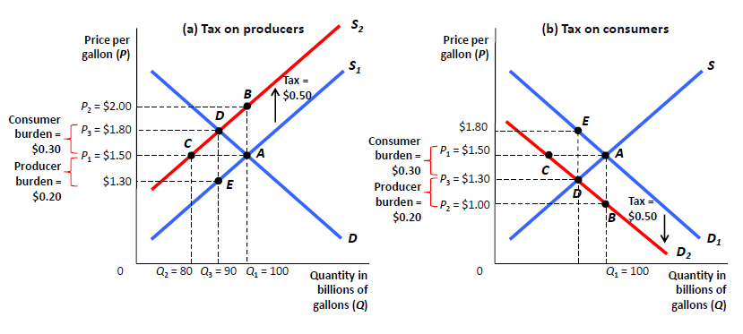

- La demanda de $x$ es $D(q)$ y disminuye con $q=p+t$. La oferta de $x$ es $S(p)$ [$S'(p)>0$]. Equilibrio:
  $$Q=S(p)=D(p+t)$$
- Suponga que $t=0$ $\longrightarrow$ $S(p)=D(p)$. **Si $t>0$:** queremos saber $dp/dt$ –efecto de un pequeño aumento de $t$ sobre $p$; esto determina quién soporta efectivamente la carga
- $dp$ responde a $dt$ para equilibrar:
  $$\begin{aligned}
  S(p+dp)=D(p+dp+dt) \\
  S(p)+S'(p)dp=D(p)+D'(p)(dp+dt) \\
  S'(p)dp=D'(p)(dp+dt) \Rightarrow \frac{dp}{dt}=\frac{D'(p)}{S'(p)-D'(p)}\\
  \end{aligned}$$
- Es util expresarlo en terminos de elasticidades ya que no tienen unidad. Sea la elasticidad precio de la demanda:
  $$\epsilon_{D}=\frac{q}{D}\frac{dD}{dq}= \frac{qD'(q)}{D(q)} < 0$$
- Y sea la elasticidad precio de la oferta:
  $$\epsilon_{S}=\frac{p}{S}\frac{dS}{dp}= \frac{pS'(p)}{S(p)} > 0$$
- Recordando la ecuación anterior:
  $$\begin{aligned}
  \frac{dp}{dt}=\frac{D'(p)}{S'(p)-D'(p)}=\frac{\epsilon_{D}}{\epsilon_{S}-\epsilon_{D}} \\
  -1 \leq \frac{dp}{dt} \leq 0 \quad y \quad 0 \leq
  \frac{dq}{dt}=1+\frac{dp}{dt} \leq 1
  \end{aligned}$$

$$\frac{dp}{dt}=\frac{\epsilon_{D}}{\epsilon_{S}-\epsilon_{D}}$$

- ¿Cuándo soportan los consumidores toda la carga? [$dp/dt=0$ y $dq/dt=1$]
  - $\epsilon_{D}=0$ [demanda inelastica] –demanda de combustible de corto plazo
  - $\epsilon_{S}=\infty$ [oferta elastica] –ind. competitiva
- ¿Cuándo soportan los productores toda la carga? [$dp/dt=-1$ y $dq/dt=0$]
  - $\epsilon_{S}=0$ [oferta inelástica] –capacidad fija y costos hundidos.
  - $\epsilon_{D}=\infty$ [demanda elástica] –sustituto perfecto

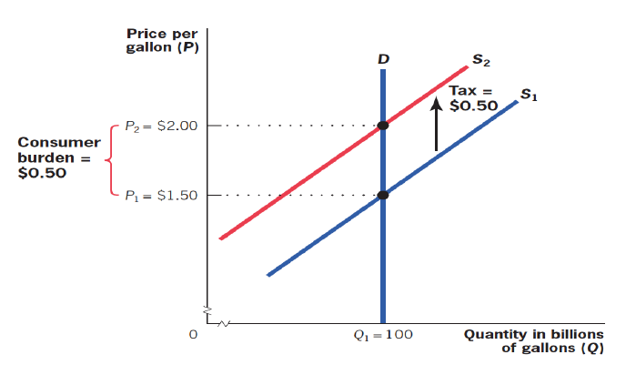

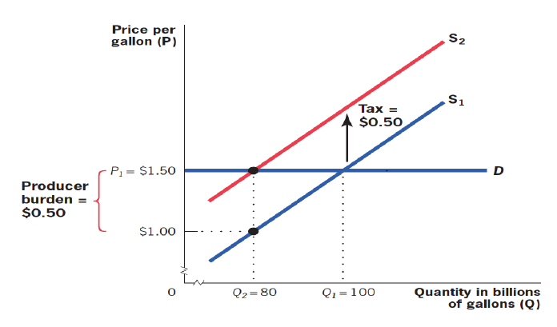

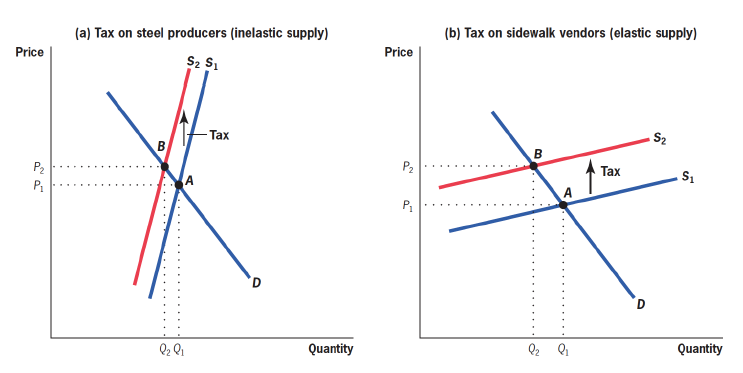

# Factores que afectan la incidencia

- **Características del mercado**
  - Estructura mdo: comp. vs monopolio
  - Grado de informalidad, competencia desleal
- **Territorio**
  - Comercio exterior (apertura de la economía)
  - Impuestos subnacionales (ej: automotor)
- La economía opera en el **tiempo**
  - Expectativas, efecto anuncio, duración del impuesto (ej: reducción del IVA por tres meses)
  - Dinámica corto plazo vs largo plazo (clave costos de ajuste).
- Comportamiento del **Gobierno**
  - Destino de RT: 1) aumentar gasto (“incidencia presupuestaria”); 2) mejorar ahorro público (“incidencia absoluta”); 3) reemplazar otros tributos (“incidencia diferencial”)
  - Políticas de la autoridad tributaria $\longrightarrow$ costos de administración y cumplimiento
  - Búsqueda de rentas $\longrightarrow$ tratamientos impositivos diferenciales –i.e promociones industriales
- Comportamiento optimizador de los **consumidores**
  - Explicitar impuestos en el precio puede cambiar el nivel de consumos –*tax salience*

# Incidencia impositiva: Costos de eficiencia impositivos

# Costos de eficiencia

- Se denomina **perdida de peso muerto** –exceso de carga- a la pérdida de bienestar creada por el impuesto sobre y por encima de la RT.
- En $O$ y $D$, bienestar medido por la suma de excedentes de productor (EP) y consumidor (EC)
- La pérdida de peso muerto (DWL, en inglés) se mide como el *cambio* en el bienestar de prod+cons menos la RT $\longrightarrow$ famoso triángulo en diagrama

> **Ineficiencia de impuestos.** Está dada por el grado en que cons. y prods. alteran conducta para evitar el impuesto –porque ambos eligen cantidades ineficientes para esquivar el impuesto –sin cambio en *Q*, no habrá DWL

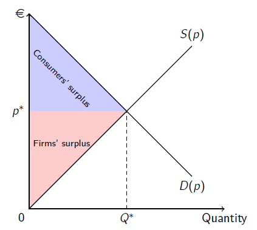

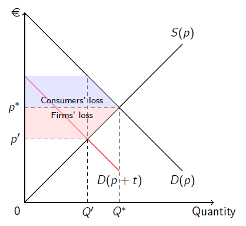

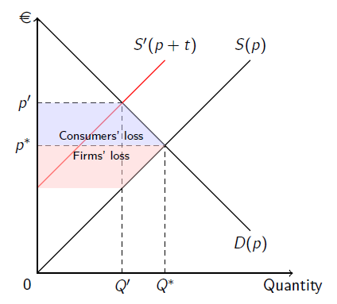

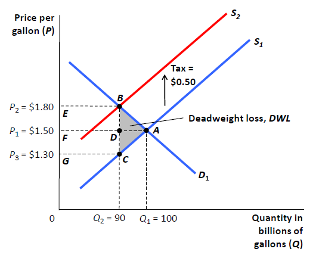

- La DWL de un pequño aumento impositivo, $dt$ (partiendo desde $t=0$) se puede medir a través del **triángulo de Haberger**
  $$DWL=\frac{1}{2}dQ.dt= \frac{1}{2}S'(p).dp.dt=\frac{1}{2}\frac{pS'(p)}{S(p)}\frac{Q}{p}.dp.dt$$
- (recuerde que $Q=S(p)$ y por tanto $dQ=S'(p)dp$)
- Y recordando que $dp/dt=\frac{\epsilon_{D}}{\epsilon_{S}-\epsilon_{D}}$:
  $$DWL=\frac{1}{2}\frac{\epsilon_{S}.\epsilon_{D}}{\epsilon_{S}-\epsilon_{D}}.\frac{Q}{p}(dt)^2$$

$$DWL=\frac{1}{2}\frac{\epsilon_{S}.\epsilon_{D}}{\epsilon_{S}-\epsilon_{D}}.\frac{Q}{p}(dt)^2$$

1. DWL aumenta con el valor absoluto de ambas elasticidades $\epsilon_{S}>0$ y $-\epsilon_{D}>0$ –mas eficiente gravar a bienes que tienen O y D mas inelásticas
2. DWL mayor con el cuadrado de la alícuota $\longrightarrow$ impuestos bajos tienen DWL menores; impuestos altos, DWL mayores –(1) más eficiente distribuir impuestos entre muchos bs. que gravar pocos; (2) mejor fondear un gasto excepcional (guerra) con deuda antes que con $T$ altos
3. Distorsiones pre-existentes hacen el costo de imposición mayor $\longrightarrow$ nos movemos de un triángulo a un trapezoide!

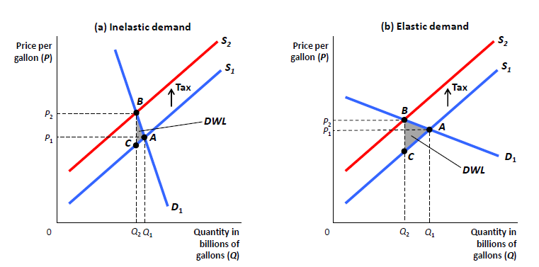

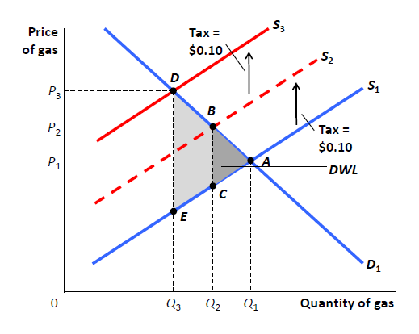

# Aplicación: Imposición óptima

> **Problema.** Un individuo consume $K$ bienes diferentes –¿cuáles son las tasas $t_{1},t_{2},...t_{K}$ para cada bien que recauda una cierta cantidad *minimizando* la perdida de bienestar individual?
- Ramsey (1927): $t$ uniformes $t_{1}=t_{2}=...=t_{K}$ no óptimas si demandas de $i$ diferente elasticidad

> **Regla de Ramsey:** $t$ óptimas son las que igualan DWL marginal de todos los bienes:
> $$MDWL_{i}=constant \quad x MR_{i}$$
- Óptimo $\longrightarrow$ gravar más fuerte los bienes inelásticos (menos a más elásticos)

# Incidencia impositiva I: Evidencia

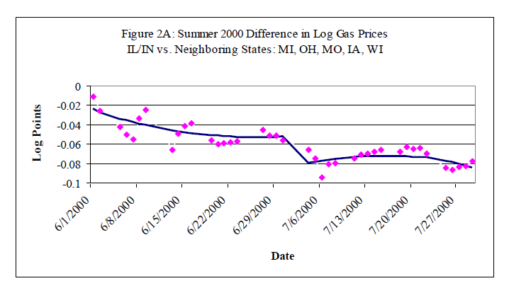

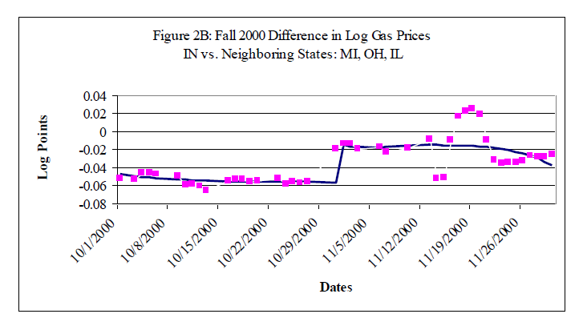

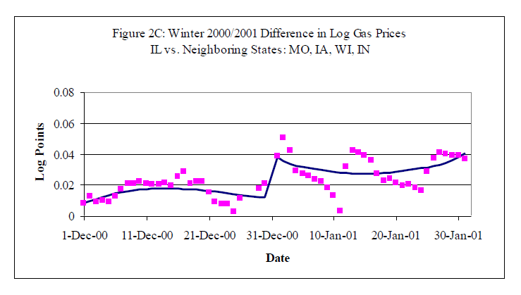

# Incidencia impositiva II: Evidencia

- Los impuestos específicos sobre cigarrillo varían fuertemente en los estados de EEUU
  - desde un bajo $0.025$ por paquete en Virginia
  - a un alto $1.51$ por paquete en Connecticut and Massachusetts
  - desde 1990, Nueva Jersey aumentó el impuesto en 6 veces
  - Arizona tambien lo aumento casi 8 veces
- Muchos estudios existentes s/este tema
- Casi todos concluyen que el precio de los cigarrillos aumenta exactamente en el monto del $T$

# Incidencia impositiva: *Tax salience*

# Incidencia: Tax salience

- Supuesto del análisis anterior: *impuestos son equivalentes a los precios*. Es decir:
  $$\frac{dD}{dt}=\frac{dD}{dp}$$
- Pero los $T$ pueden tener diferentes efectos en $D$ sin que los consumidores se den cuenta o no. ¿Las personas son conscientes de las alícuotas marginales que enfrentan?

> **Tax salience.** El impuesto $a$ es more *saliente* que el impuesto $b$ si el cálculo del precio bruto con impuestos bajo $a$ requiere menos cómputos que el cálculo del precio bruto con impuestos bajo $b$.
- Chetty, Looney and Kroft (2009) testean este supuesto y generalizan la teoría para permitir *salience effects*
- Primera parte $\longrightarrow$ testear si la *salience* –visibilidad del precio bruto con $T$- afecta al comportamiento cuando se imponen a bienes
  - ¿El efecto de un impuesto sobre el consumo depende de si está incluido en el **precio impreso**?
- Segunda parte $\longrightarrow$ desarrollan formulas de incidencia y costos de eficiencia que permiten *salience effects* y otros errores de optimizacion
- Modelo de economia con 2 bienes, $x$ e $y$. Normalizan el precio de $y$ a 1 y sea $p$ el precio (fijo) antes de impuesto de $x$.
- Impuestos $\longrightarrow$ $y$ no sujeto a imposicion; $x$ sujeto a un impuesto *ad-valorem* a las ventas, $\tau$ (no incluido en el precio impreso)
  - Precio con $T$ incluido de $x$ es $q=(1+\tau)p$
- Sea $x(p,\tau)$ la demanda del bien $x$
- Si los agentes optimizan totalmente, la demanda debería depender sobre el precio con impuesto incluido, es decir, $x(p,\tau)=x((1+\tau)p,0)$
- La optimizacion total implica que la elasticidad precio iguala la elasticidad precio con impuestos:
  $$\epsilon_{x,p}=-\frac{\partial \log x}{\partial \log
  p}=\epsilon_{x,1+\tau}=-\frac{\partial \log x}{\partial \log (1+\tau)}$$
- Log-linearizamos la fn de demanda $x(p,\tau)$ para obtener la ecuación a estimar:
  $$\log x(p,\tau)=\alpha +\beta \log p + \theta\beta \log (1+\tau)$$
- $\theta$ mide el grado en que los consumidores *sub-reaccionan* al impuesto:
  $$\theta=\frac{\partial \log x}{\partial \log (1+\tau)}/\frac{\partial
  \log x}{\partial \log p}=\frac{\epsilon_{x,1+\tau}}{\epsilon_{x,p}}$$
- Proponen dos estrategias para estimar $\theta$:
  - **Manipular la *tax salience*** $\longrightarrow$ mostrar el $T$ tan visible como el precio antes de $T$
    - Efecto de la intervencion sobre $D$
      $$v=\log x((1+\tau)p,0)-\log x(p,\tau)$$
    - Compare con el efecto de incremento equivalente de precio para estimar $\theta$:
      $$(1-\theta)=-\frac{v}{\epsilon_{x,p}\log(1+\tau)}$$
  - **Manipular la alícuota** $\longrightarrow$ comparar $\epsilon_{x,p}$ y $\epsilon_{x,1+\tau}$ para calcular:
    $$\theta=\epsilon_{x,1+\tau}/\epsilon_{x,p}$$

[figure not shown]

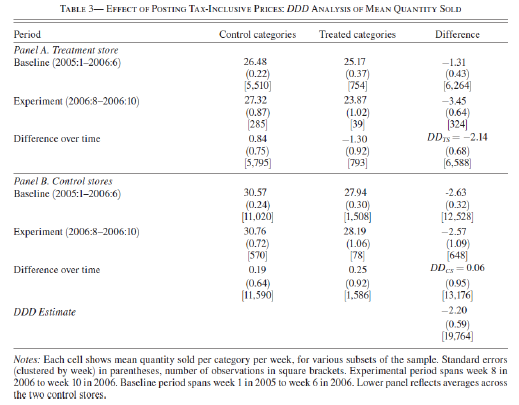

> **La segunda estrategia.** Manipulan alícuotas La idea era comparar efectos diferenciales de cambios de precios y cambios de impuestos. La imposición al alcohol es util aqui ya que está sujeta a dos impuestos estatales en EEUU: 1) impuesto especifico (incluido en el precio); 2) impuesto a las ventas (agregado en la caja, no mostrado en el precio impreso)
- Se explotan cambios en los dos impuestos al nivel de estado y se permite estimar $\theta$

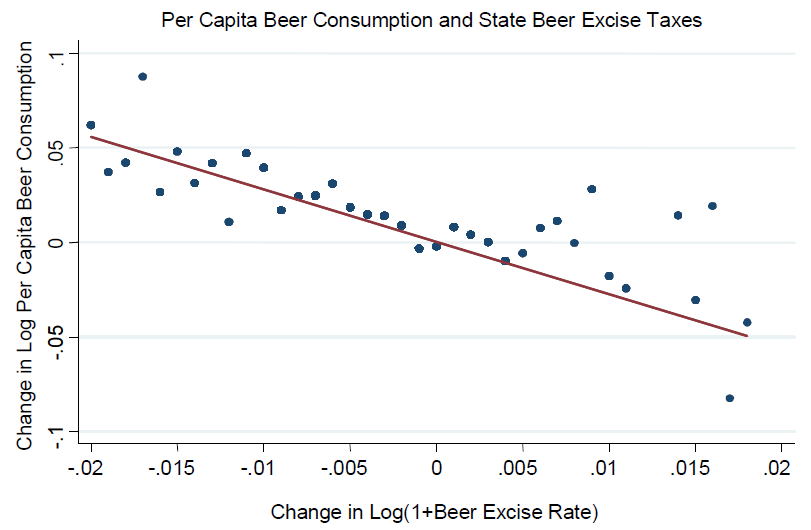

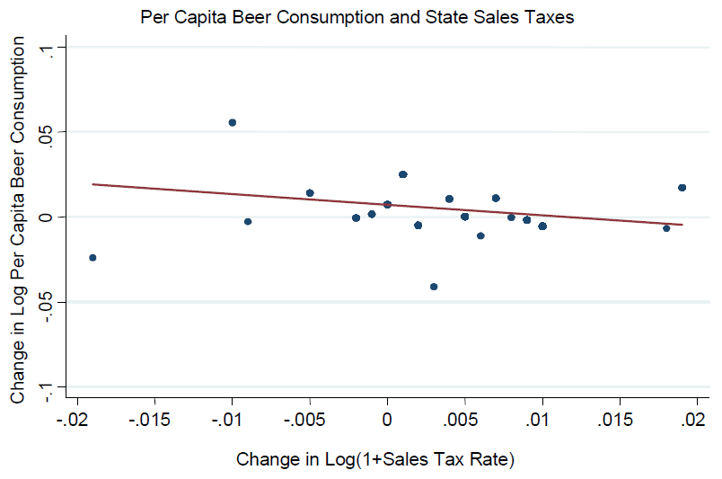

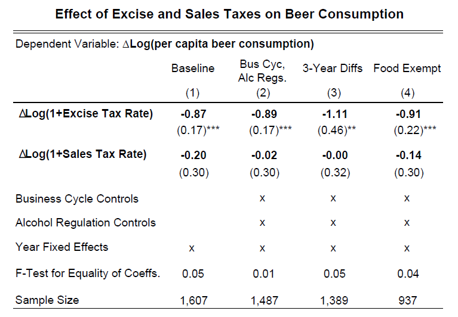

- Principal resultado $\longrightarrow$ la *salience* importa!
- Resultados adicionales $\longrightarrow$ los cambios de precios y los cambios de impuestos tienen asociados efectos diferentes
- A todo nivel, el cambio en la demanda es mayor mientras mas *visible* es el impuesto
- Otros resultados concluyentes $\longrightarrow$ los impuestos sobre los productores tienen mayor incidencia sobre los productores que impuestos *no salientes* aplicados a los consumidores
- Suponga que
  $${x(p,t,Z),y(p,t,Z)}$$
  son demandas empíricamente observadas. Ninguna estructura salvo que sean posibles:
  $$(p+t)x(p,t,Z)+y(p,t,Z)=Z$$
- La oferta son las mismas que en modelos anteriores. El precio que equilibra el mercado satisface:
  $$D(p,t,Z)=S(p)$$
- donde $D(p,t,Z)=x(p,t,Z)$ es la demanda de mercado para $x$.

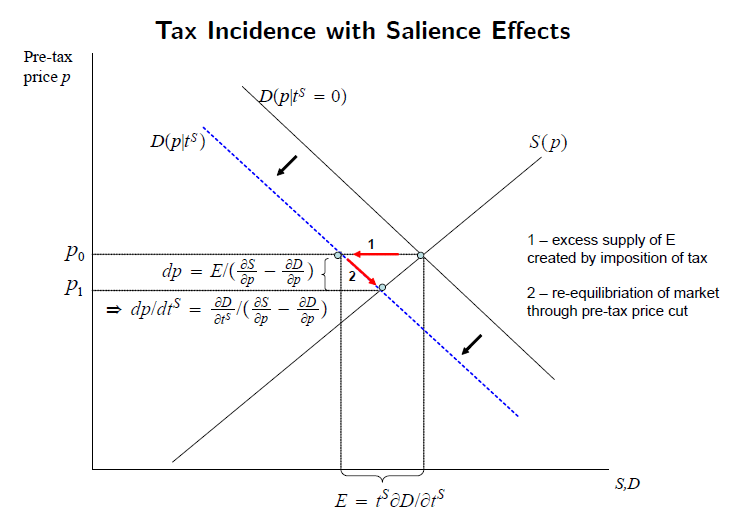

- La incidencia sobre los productores de un $\tau$ creciente es:
  $$\frac{dp}{dt}=\frac{\partial D/\partial t}{\partial S/\partial
  p-\partial D/\partial p}=-\theta
  \frac{\epsilon_{D}}{\epsilon_{S}-\epsilon_{D}}$$
- Note que se dan los siguientes resultados:
  1. La incidencia sobre los productores es atenuada por la existencia de $\theta$
  2. No neutralidad del impuesto $\longrightarrow$ los impuestos sobre los productores tienen mayor incidencia sobre los productores que impuestos *no salientes* aplicados a los consumidores
- Intuición $\longrightarrow$ productores necesitan recortar el precio *antes de impuesto* cuando los consumidores son menos sensibles al $T$

# Incidencia impositiva: Equilibrio general

# Incidencia: Equilibrio general

- Hasta ahora hemos visto incidencia en *equilibrio parcial* $\longrightarrow$ focaliza en un mercado aislado
- Eq general considera efectos de $T$ en otros mdos $\longrightarrow$ efectos de $T$ a los autos puede reducir la $D$ de acero –efectos s/ $P$ más allá del mdo de autos
- Considere el mdo de gaseosas en Berkeley; se creó un $T$ a las gaseosas. ¿Quién soporta la carga? Si $D$ inelastica, los consumidores. Pero $D$ gaseosas es elástica $\longrightarrow$ si $P$ gaseosas en Berkeley sube, sus habitantes compran menos o consumen en Oakland.
- Si $D$ fuera perfectamente elástica, ¿que pasaria?

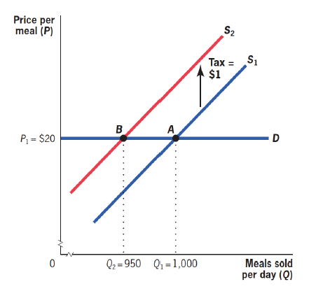

- Si la demanda es perfectamente elástica, entonces.
  1. Los vendedores de gaseosas en Berkeley soportan toda la carga del impuesto
  2. Pero los vendedores de gaseosas no son entidades auto-contenidas –en todos esos lugares se combinan factores (K y L) para vender gaseosas
  3. Ambos factores deberán sufrir el costo en terminos de beneficios debido al impuesto
- Entonces la incidencia es trasladada “hacia atrás” a los factores productivos que producen el bien gravado
- Si la oferta de trabajo es perfectamente elástica –dado que los trabajadores de Berkeley pueden moverse sin costo a Oakland si les bajan salario en Berkeley.
- El capital, en cambio, es perfectamente inelástico en el corto plazo $\longrightarrow$ no podes desmantelar negocio sin costos. Al ser completamente inelastico, el K sufre toda la carga –pierden los empresarios dueños de negocios
- En el LP, la oferta de K es elastica $\longrightarrow$ productores/empresarios pueden vender y reasignar a otro rubro.
- ¿Que pasa en el LP? Si L y K son ambos elásticos en el LP, ¿quién soporta la carga?
- El unico factor inelastico en ese caso es la tierra $\longrightarrow$ oferta fija
- Cuando tanto L y K pueden esquivar el impuesto, la unica forma en que los vendedores se quedarán en Berkeley será si pueden pagar un alquiler menor sobre la tierra
- En el equilibrio general de LP, el impuesto a las bebidas gaseosas termina perjudicando a los propietarios de la tierra en Berkeley
- En conclusión, efectos de equilibrio general muy importantes y poco estudiados cuando se evalúan políticas públicas